# VAR Project

### How Strong is the Causal Relationship?

To evaluate the strength of the causal relationship between Florida housing permits and construction employment, we can run a FEVD model, IRF model, and rolling spillover index. The forecast error variance decomposition (FEVD) model shows the variance in the pattern for each variable and how reliant that pattern is on each other. An Impulse Response Function (IRF) model measures the impact of a shock in one variable on the other. The spillover plot depicts the connectedness between the variables.

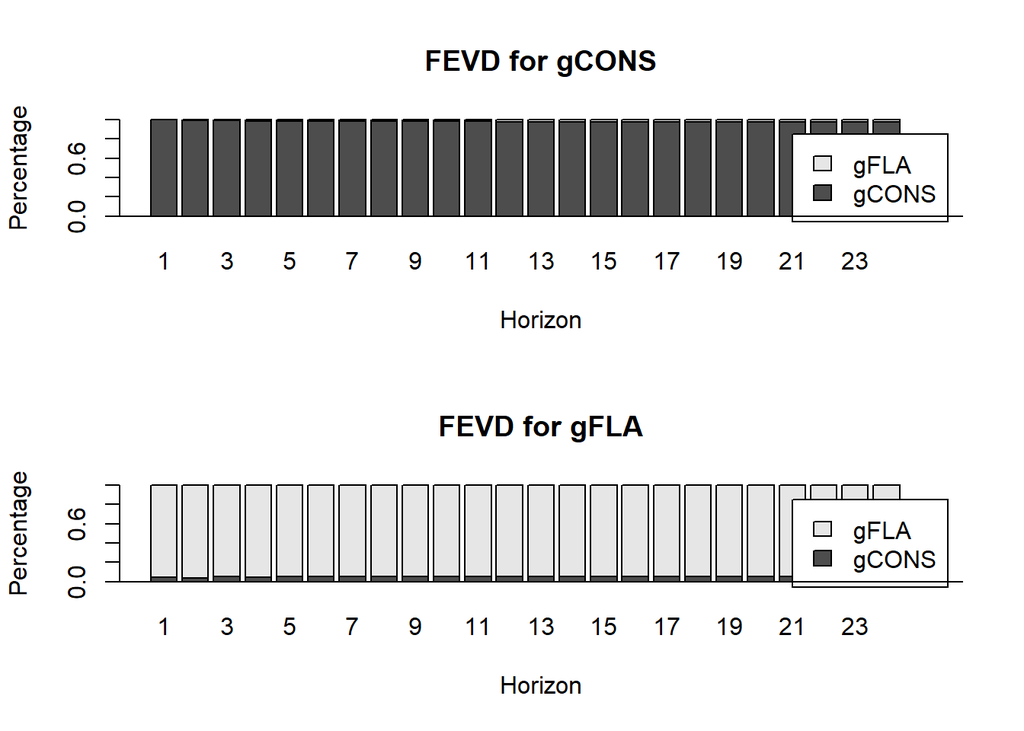

```r
plot(fevd(var.data, n.ahead = 24))
```

The output from the FEVD model above shows that very little of the variance in each variable is explained by the other.

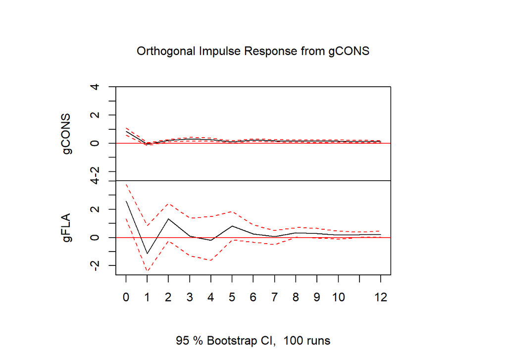

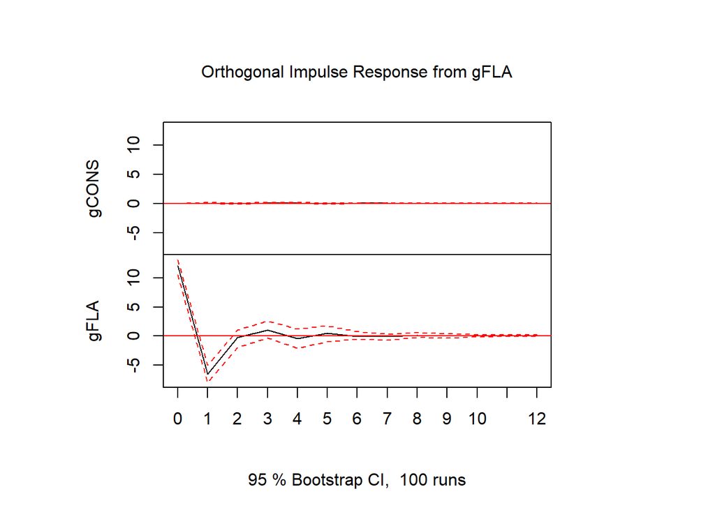

```r
irf.fla <- irf(var.data, n.ahead = 12)

plot(irf.fla)
```

The IRF model output depicts the reaction from each variable when there is a shock in the other. Shocks to housing permits does not seem to cause too much movement in construction employment. Movement in both variables even out to a constant state after each shock.

```r
spilloverDY12(var.data, n.ahead = 100, no.corr = FALSE)
```

```
## The spillover table has no frequency bands, standard Diebold & Yilmaz.
##
##
## |      | gCONS|  gFLA| FROM|
## |:-----|-----:|-----:|----:|
## |gCONS | 91.02|  8.98| 4.49|
## |gFLA  |  5.30| 94.70| 2.65|
## |TO    |  2.65|  4.49| 7.14|
```

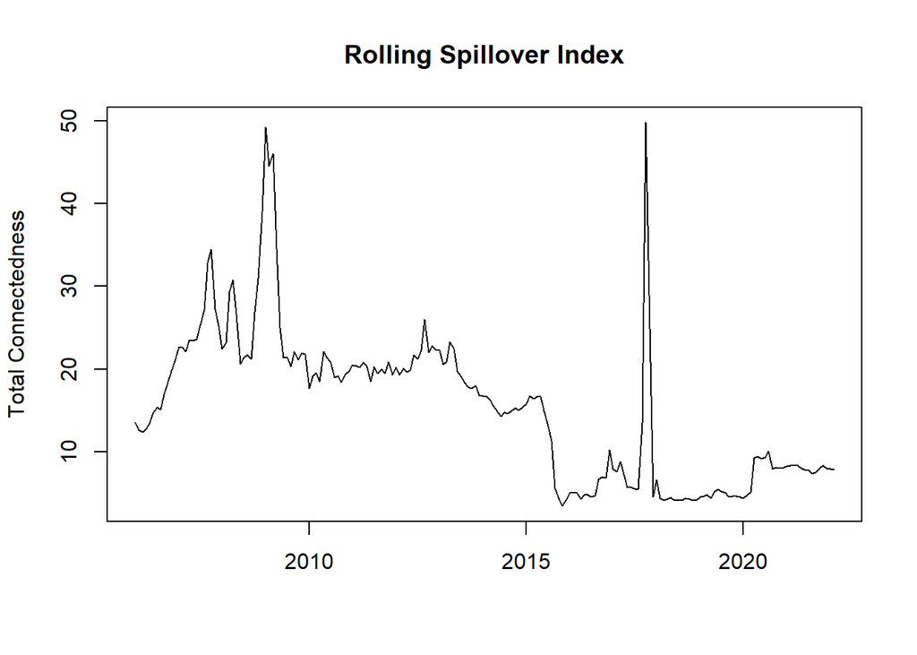

```r
sproll <- spilloverRollingDY12(data = growthr, n.ahead = 120, no.corr = F,
func_est = "VAR", params_est = list(p = p, type = "const"), window = 84)

spillover <- overall(sproll)
spillovers <- index(growthr)[84:length(index(growthr))]
plot(spillovers,spillover[[1]],type="l",xlab="",ylab = "Total Connectedness", main = "Rolling Spillover Index")
```

The spillover plot shows that the variables have very high or low connectedness at different points in time.

We know that Florida housing build permits and Florida construction employment share a relationship, but the tests above show that construction employment may not be as reliant on permits as previously expected.